# Praca domowa 2

Aleksander Luckner

## Dane

Dane wykorzystane w Pracy domowej 2 opisują wycenę nieruchmości. Każda obserwacja jest pewną nieruchmością, która posiada informacje takie jak powierzchnia, liczba pokoi, liczba łazienek i wiele więcj. Opis wszystkich kolumn w pliku `README.md`.

## Zadanie 1

Jak wygląda rozkład ceny nieruchomości w poszczególnych kodach pocztowych na przestrzeni lat? Rozważamy kody pocztowe, które mają więcej niż 280 posiadłości.

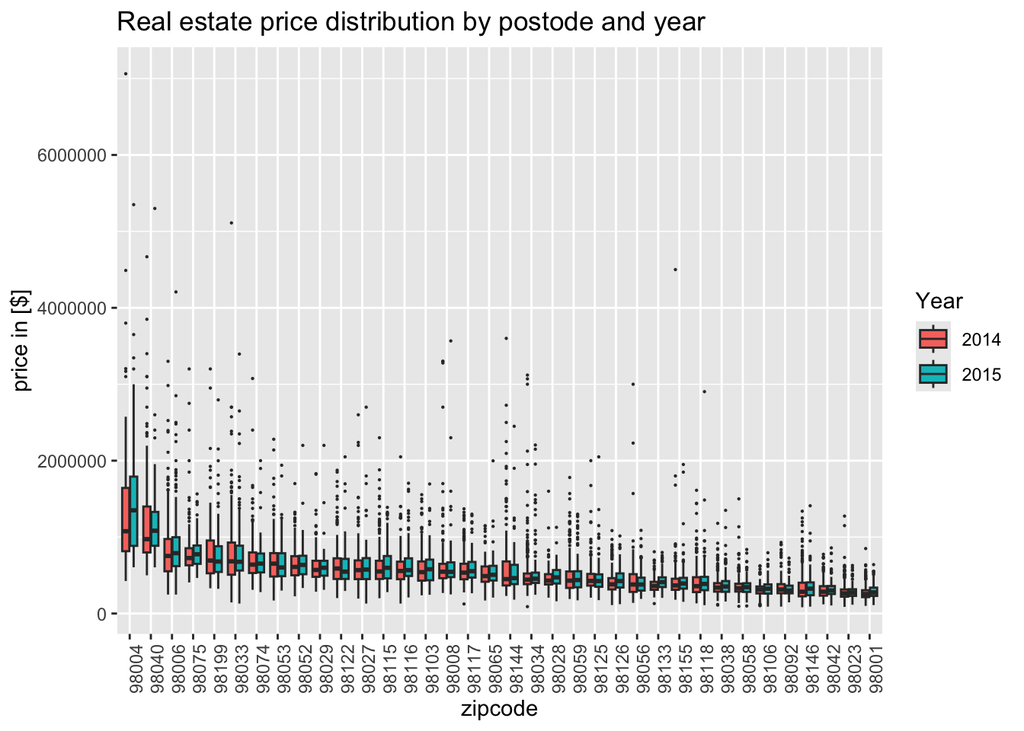

```r
# Tu umieść kod do wygenerowania odpowiedzi do zadania.
tmp_df1 <- df%>%
  group_by(zipcode)%>%
  summarise(n_zipcode = n())

tmp_df2 <- df%>%
  left_join(tmp_df1, by = "zipcode")%>%
  filter(n_zipcode > 280)%>%
  mutate(Year = substr(date, 1, 4))%>%
  group_by(zipcode, Year) %>%
  select(zipcode, Year, price)

df_median <- tmp_df2 %>%
  group_by(zipcode) %>%
  summarise(median_price = median(price)) %>%
  arrange(desc(median_price))

tmp_df2$zipcode=factor(tmp_df2$zipcode,
                       levels = df_median$zipcode,
                       ordered = TRUE)

ggplot(tmp_df2,
       aes(x = zipcode, y = price, fill = Year)) +
  geom_boxplot(outlier.size = 0.1) +
  labs(title = "Real estate price distribution by postode and year",
       y = "price in [$]") +
  theme(axis.text.x = element_text(angle = 90, hjust = 1))
```

**Komentarz:** Nie ma znaczących różnic. Występują pojedyńcze dane odstające, które nie zależą od roku. Możemy jednak zauważyć, że w zależności od regionu ceny mieszkań mogą się znacząco różnić.

## Zadanie 2

Czy jest różnica w rozkładzie ceny nierchomości od powierzchni mieszkalnej uwzględniając podział na nieruchomości z piwnicą i bez?

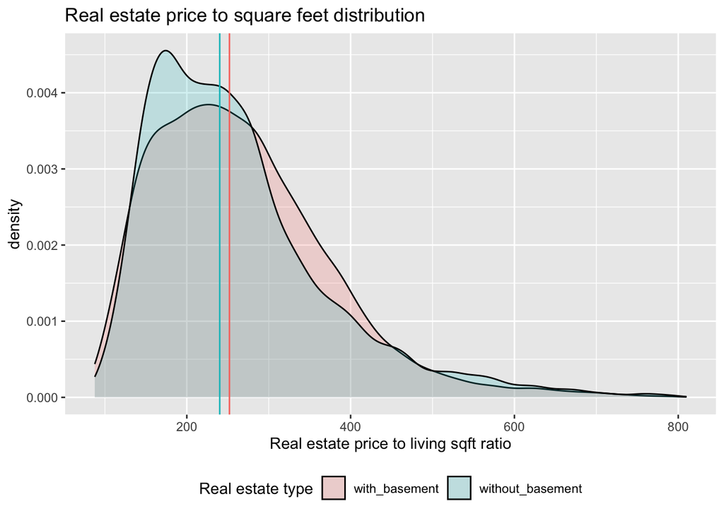

```r
# Tu umieść kod do wygenerowania odpowiedzi do zadania.
tmp_df1 <- df %>%
  mutate(basement = ifelse(sqft_basement > 0, "with_basement", "without_basement"),
         price_livingsqft_ratio = price/sqft_living) %>%
  select(basement, price_livingsqft_ratio)

df_median <- tmp_df1 %>%
  group_by(basement) %>%
  summarise(basement_median = median(price_livingsqft_ratio))

ggplot(tmp_df1,
       aes(x = price_livingsqft_ratio, fill = basement)) +
  geom_density(alpha = .2) +
  labs(title = "Real estate price to square feet distribution",
       x = "Real estate price to living sqft ratio",
       fill = "Real estate type") +
  theme(legend.position = "bottom") +
  geom_vline(data=df_median,
             aes(xintercept = basement_median,
                 color = basement)) +
  guides(color = "none")
```

**Komentarz:** Nie ma znaczącej różnicy w rozkładzie ceny nieruchomości od powierzchni mieszkalnej. Mediany są do siebie zbliżone a rozkłady wyższych wyższych cen za stopę kwardatową się pokrywają.

## Zadanie 3

Jaka jest zależność pomiędzy jakością wykończenia nieruchomości a liczbą pięter?

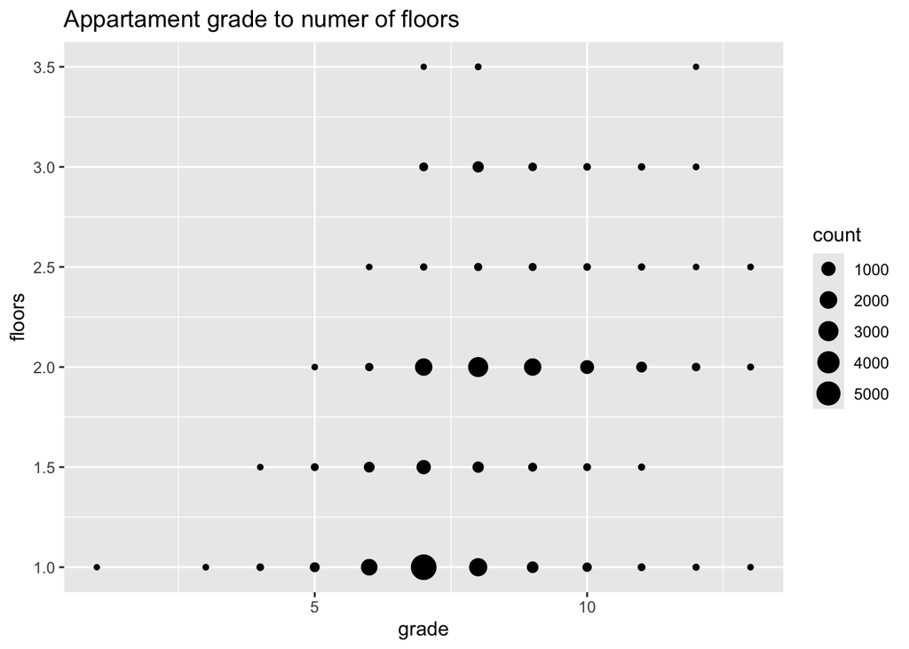

```r
# Tu umieść kod do wygenerowania odpowiedzi do zadania.
df2 <- df %>%
  select(floors, grade) %>%
  group_by(grade, floors) %>%
  summarise(count = n())


  ggplot(df2,aes(x = grade, y=floors, size = count)) +
    geom_point() +
    labs(title = "Appartament grade to numer of floors")
```

**Komentarz:** Najpopularniejsze są domy o średnim poziomie wykończenia mające do dwóch pięter. Dodatkowo wraz ze wzrostem liczby pięter rośnie jakość wykończenia domu. Nie dotyczy to największych domów. Brak tendencji dla największych domów możę wynikać z małej liczby takich domów, co daje niewystarczającą próbkę do porównania z pozostałymi domami.

## Zadanie 4

Jaka jest zależność między powierzchnią mieszkalną nieruchomości a powierzchnią gruntu w podziale na liczbę sypialni?

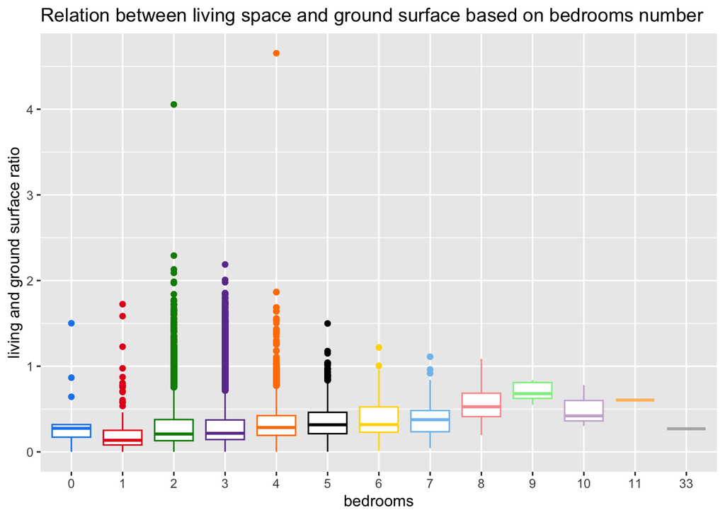

```r
# Tu umieść kod do wygenerowania odpowiedzi do zadania.
tmp_df1 <- df %>%
  mutate(living_to_lot = sqft_living/sqft_lot)

tmp_df1$bedrooms=factor(tmp_df1$bedrooms,
                       ordered = TRUE)

ggplot(tmp_df1,
       aes(x = bedrooms,
           y = living_to_lot,
           colour = bedrooms))+
  geom_boxplot() +
  scale_color_manual(values=c("dodgerblue2", "#E31A1C", # red
  "green4",
  "#6A3D9A", # purple
  "#FF7F00", # orange
  "black", "gold1",
  "skyblue2", "#FB9A99", # lt pink
  "palegreen2",
  "#CAB2D6", # lt purple
  "#FDBF6F", # lt orange
  "gray70", "khaki2",
  "maroon", "orchid1", "deeppink1", "blue1", "steelblue4",
  "darkturquoise", "green1", "yellow4", "yellow3",
  "darkorange4", "brown")) +
  theme(legend.position = "none") +
  labs(title = "Relation between living space and ground surface based on bedrooms number",
       y = "living and ground surface ratio")
```

**Komentarz:** Dla mieszkań z co najmniej jedną sypialnią rejestrowany jest wzrost mediany stosunku powierzchni mieszkalnej z powierzchnią gruntu dla mieszkań z większą liczbą sypialni. Nie dotyczy to mieszkań mających co najmniej dziesięć sypialni.

## Zadanie 5

Rozważmy tylko nieruchomości, które miały remont. W której dekadzie było najwięcej przeprowadzonych remontów? Czy w poszczególnych dekadach jest porównywalny procent nieruchmości dla każdej wartości miary jakości i wykończenia nieruchomości?

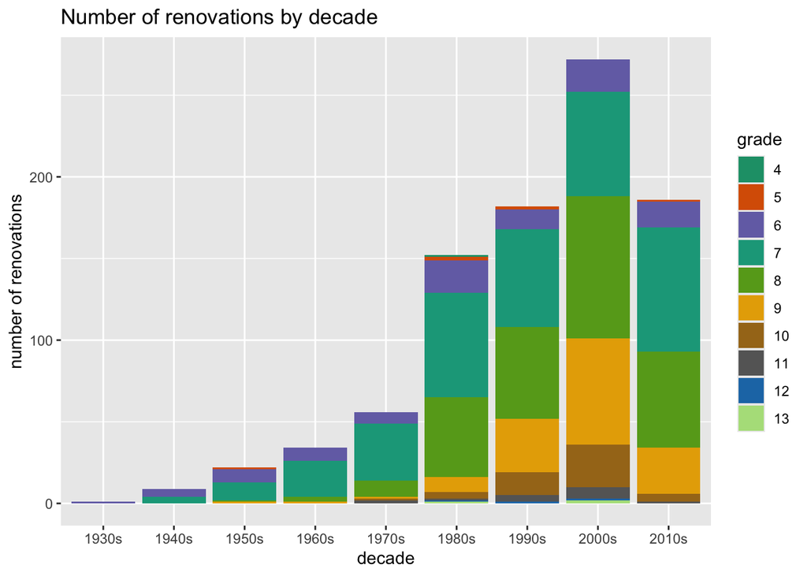

```r
# Tu umieść kod do wygenerowania odpowiedzi do zadania.
tmp_df1 <- df %>%
  filter(yr_renovated > 0) %>%
  mutate(decade = paste0((yr_renovated %/% 10) * 10, "s")) %>%
  group_by(decade, grade) %>%
  summarise(n_renovations = n())

tmp_df1$decade=factor(tmp_df1$decade,
                      ordered = TRUE)

tmp_df1$grade=factor(tmp_df1$grade,
                      ordered = TRUE)

ggplot(tmp_df1, aes(x = decade, y = n_renovations, fill = grade))+
  geom_col() +
  labs(title = "Number of renovations by decade",
       y = "number of renovations")+
  scale_fill_manual(values=c("#1b9e77", "#d95f02", "#7570b3", "#17a589", "#66a61e",
            "#e6ab02", "#a6761d", "#666666", "#1f78b4", "#b2df8a"))
```

**Komentarz:** W każdej kolejnej dekadzie liczba remontów wzrasta z wykluczeniem ostatniej. Spadek w ostatniej dekadzie wynika z faktu, że dane zebrane są do 2015 roku. Dodatkowo na przestrzeni dekad rejestrowana jest niewielka poprawa oceny jakości i wykończenia nieruchomości.

## Zadanie 6

Jak prezentuje się wartość minimalna, średnia i maksymalna ceny nieruchmości w podziele na rok budowy nieruchomości.

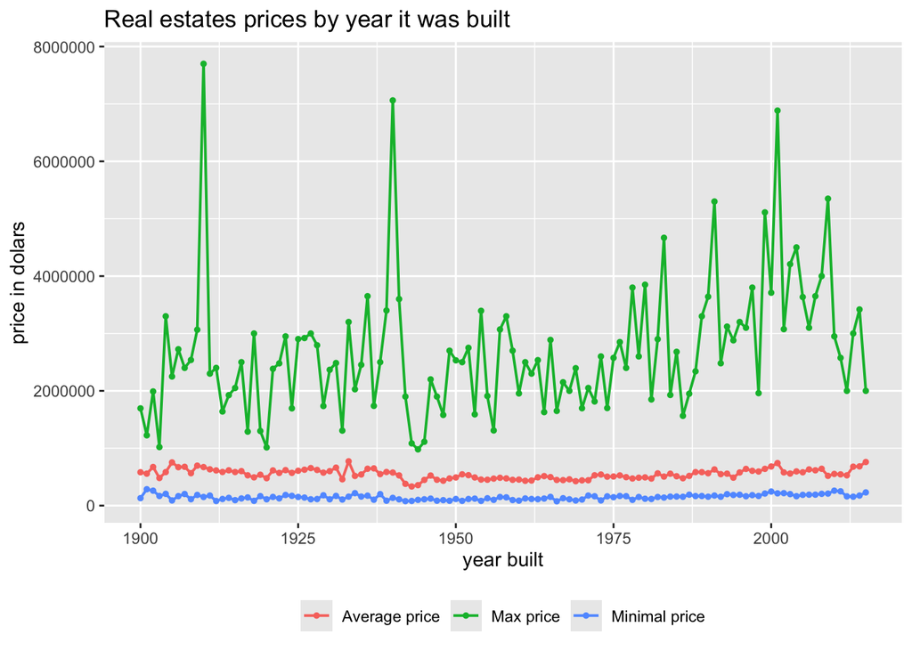

```r
# Tu umieść kod do wygenerowania odpowiedzi do zadania.
tmp_df1 <- df %>%
  group_by(yr_built) %>%
  summarise(min_price = min(price),
            avg_price = mean(price),
            max_price = max(price))

ggplot(tmp_df1, aes(x = yr_built)) +
  geom_line(aes(y = min_price, color = "Minimal price"),
            linewidth = .7) +
  geom_line(aes(y = avg_price, color = "Average price"),
            linewidth = .7) +
  geom_line(aes(y = max_price, color = "Max price"),
            linewidth = .7) +
  geom_point(aes(y = min_price, color = "Minimal price"),
             size = 1) +
  geom_point(aes(y = avg_price, color = "Average price"),
             size = 1) +
  geom_point(aes(y = max_price, color = "Max price"),
             size = 1) +
    labs(
    title = "Real estates prices by year it was built",
    x = "year built",
    y = "price in dolars") +
  theme(legend.position = "bottom") +
  guides(color = guide_legend(title = NULL))
```

**Komentarz:** Rok budowy nieruchomości nie ma znaczącego wpływu na jej minimalną czy średnią cenę. Maksymalna cena również nie jest powiązana z rokiem i pojedyńcze lata w wysoką ceną najdroższych mieszkań wynikają z czegoś innego niż rok budowy.